# 1. Install Dependencies and Setup

```python
#Ensure you establish a V enviornment prior to running and ensure all dependencies and kernels are live.
```

```python
!pip install tensorflow opencv-python matplotlib
```

```python
!pip list
```

[output not shown]

[output cut: 75 more lines]

[output not shown]

```python
import tensorflow as tf
import os
```

```python
# Import TensorFlow library for creating neural networks
import tensorflow as tf

# Get a list of physical GPUs available on the computer
gpus = tf.config.experimental.list_physical_devices('GPU')

# Print the list of available GPUs to the console
print("List of GPUs Available: ", gpus)

# Set memory growth for each GPU to avoid running out of memory (OOM) errors
# This loop sets memory growth for each GPU to be dynamic, meaning that the memory
# usage will increase as needed, but will be released when it's no longer needed
for gpu in gpus:
    tf.config.experimental.set_memory_growth(gpu, True)

# Check if there are any physical GPUs available and print the list to the console
tf.config.list_physical_devices('GPU')
```

```
List of GPUs Available:  []
```

```
[]
```

# 2. Remove dodgy images

```python
# Import OpenCV library for image processing
import cv2

# Import imghdr library for checking the image file type
import imghdr
```

```python
# Define a variable `data_dir` and set its value to the string 'data'
data_dir = 'data'

# Print the value of `data_dir` to the console
print(data_dir)
```

```
data
```

```python
# Define a list of image file extensions
image_exts = ['jpeg', 'jpg', 'bmp', 'png']
```

```python
# Loop through each subdirectory in the data directory
for image_class in os.listdir(data_dir):

    # Loop through each image file in the current subdirectory
    for image in os.listdir(os.path.join(data_dir, image_class)):

        # Combine the path to the image file with the path to the subdirectory
        image_path = os.path.join(data_dir, image_class, image)

        # Try to read in the image file using OpenCV and determine its file type
        try:
            img = cv2.imread(image_path)
            tip = imghdr.what(image_path)

            # If the file type is not in the list of valid image file extensions, remove the file
            if tip not in image_exts:
                print('Image not in ext list {}'.format(image_path))
                os.remove(image_path)

        # If there is an error reading in the image file, remove the file
        except Exception as e:
            print('Issue with image {}'.format(image_path))
            os.remove(image_path)
```

# 3. Load Data

```python
# Import the NumPy library for numerical operations
import numpy as np

# Import the Pyplot module from the Matplotlib library for data visualization
from matplotlib import pyplot as plt
```

```python
# Use the `image_dataset_from_directory()` function to create a TensorFlow dataset
data = tf.keras.utils.image_dataset_from_directory('data')
```

```
Found 29363 files belonging to 2 classes.
```

```python
# Create an iterator from the TensorFlow dataset
data_iterator = data.as_numpy_iterator()
```

```python
# Retrieve the next batch of data from the iterator
batch = data_iterator.next()
```

[figure not shown]

```python
# Create a figure with four subplots
fig, ax = plt.subplots(ncols=4, figsize=(20,20))

# Iterate over the first four images and labels in the batch
for idx, img in enumerate(batch[0][:4]):

    # Display the current image and label in the corresponding subplot
    ax[idx].imshow(img.astype(int))
    ax[idx].title.set_text(batch[1][idx])
```

# 4. Scale Data

```python
# Use the `map()` method to apply a lambda function to the 'data' dataset to normalize the pixel values of the image
data = data.map(lambda x, y: (x / 255, y))
```

[output not shown]

```python
# Retrieve the next batch of data from the normalized dataset
data.as_numpy_iterator().next()
```

[output not shown]

[output cut: 255 more lines]

[output not shown]

# 5. Split Data

```python
# Calculate the sizes of the training, validation, and test sets as percentages of the total dataset size
train_size = int(len(data) * 0.7)
val_size = int(len(data) * 0.2)
test_size = int(len(data) * 0.1)
```

```python
# Print the sizes of the dataset and the training, validation, and test sets
print("Total Dataset Size:", len(data))
print("Training Set Size:", train_size)
print("Validation Set Size:", val_size)
print("Test Set Size:", test_size)
```

```
Total Dataset Size: 918
Training Set Size: 642
Validation Set Size: 183
Test Set Size: 91
```

```python
# Split the dataset into training, validation, and test sets
train = data.take(train_size)
val = data.skip(train_size).take(val_size)
test = data.skip(train_size + val_size).take(test_size)
```

# 6. Build Deep Learning Model

```python
train
```

```
<TakeDataset element_spec=(TensorSpec(shape=(None, 256, 256, 3), dtype=tf.float32, name=None), TensorSpec(shape=(None,), dtype=tf.int32, name=None))>
```

```python
# Import the necessary modules and classes from the TensorFlow Keras library for building a CNN
from tensorflow.keras.models import Sequential
from tensorflow.keras.layers import Conv2D, MaxPooling2D, Dense, Flatten, Dropout

# `Sequential` is a class that represents a linear stack of layers in a machine learning model.
# It is commonly used for building CNNs, where the layers are arranged in a sequential order to create a hierarchical feature representation of the input data.

# `Conv2D` is a class that represents a 2D convolutional layer in a CNN.
# It applies a set of learned filters to the input image, allowing the model to detect specific patterns and features in the image.

# `MaxPooling2D` is a class that represents a 2D max pooling layer in a CNN.
# It downsamples the output of a convolutional layer by taking the maximum value of a set of adjacent pixels, reducing the spatial dimensions of the feature maps.

# `Dense` is a class that represents a fully connected layer in a neural network.
# It takes the output of the preceding layer and applies a set of learned weights to generate a set of output values.

# `Flatten` is a class that flattens the output of a preceding layer into a 1D array, which can be passed to a fully connected layer.

# `Dropout` is a regularization technique that randomly drops out some of the output units of a layer during training, reducing the risk of overfitting.

# These classes will be used to define the architecture of a CNN for the task of image classification.
```

```python
# Create a new Sequential model
model = Sequential()
```

```python
# Add layers to the Sequential model to define the architecture of a CNN for image classification

# Add a Conv2D layer with 16 filters of size 3x3 and a ReLU activation function.
# The layer takes input of shape (256, 256, 3) and has a stride of 1.
model.add(Conv2D(16, (3,3), 1, activation='relu', input_shape=(256,256,3)))

# Add a MaxPooling2D layer that downsamples the output of the previous layer.
model.add(MaxPooling2D())

# Add a Conv2D layer with 32 filters of size 3x3 and a ReLU activation function.
# The layer has a stride of 1.
model.add(Conv2D(32, (3,3), 1, activation='relu'))

# Add a MaxPooling2D layer that downsamples the output of the previous layer.
model.add(MaxPooling2D())

# Add a Conv2D layer with 16 filters of size 3x3 and a ReLU activation function.
# The layer has a stride of 1.
model.add(Conv2D(16, (3,3), 1, activation='relu'))

# Add a MaxPooling2D layer that downsamples the output of the previous layer.
model.add(MaxPooling2D())

# Add a Flatten layer that flattens the output of the previous layer into a 1D array.
model.add(Flatten())

# Add a Dense layer with 256 units and a ReLU activation function.
model.add(Dense(256, activation='relu'))

# Add a Dense layer with 1 unit and a sigmoid activation function.
model.add(Dense(1, activation='sigmoid'))
```

optimizer: This is the optimizer algorithm used to optimize the model's parameters during training. Here, we specify the adam optimizer, which is a popular choice for training deep neural networks.

loss: This is the loss function used to compute the error between the model's predictions and the true labels during training. Here, we specify the BinaryCrossentropy() loss function, which is commonly used for binary classification problems.

metrics: This is the evaluation metric used to measure the model's performance on the validation and test sets. Here, we specify the accuracy metric, which measures the proportion of correct predictions out of all predictions.

```python
# Compile the model by specifying the optimizer, loss function, and evaluation metric
model.compile('adam', loss=tf.losses.BinaryCrossentropy(), metrics=['accuracy'])
```

```python
model.summary()
```

[output not shown]

# 7. Train

```python
logdir='logs'
```

In the below code block, we train the previously defined Sequential model on the training dataset (train) for 20 epochs using the fit() method.

The epochs parameter specifies the number of times to iterate over the entire training dataset during training. Each epoch consists of one forward pass and one backward pass (gradient update) through the entire training dataset. Increasing the number of epochs can improve the model's accuracy on the training set, but may also increase the risk of overfitting.

The validation_data parameter specifies the validation set (val) to use for evaluating the model's performance during training. The model's loss and accuracy are computed on this set at the end of each epoch.

The callbacks parameter specifies a list of callbacks to use during training. Here, we include a TensorBoard callback (tensorboard_callback) for monitoring the training progress and visualizing the results in the TensorBoard tool.

```python
tensorboard_callback = tf.keras.callbacks.TensorBoard(log_dir=logdir)
```

```python
hist = model.fit(train, epochs=20, validation_data=val, callbacks=[tensorboard_callback])
```

# 8. Plot Performance

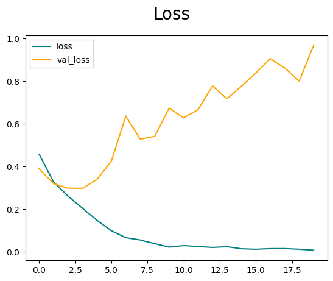

```python
fig = plt.figure()
plt.plot(hist.history['loss'], color='teal', label='loss')
plt.plot(hist.history['val_loss'], color='orange', label='val_loss')
fig.suptitle('Loss', fontsize=20)
plt.legend(loc="upper left")
plt.show()
```

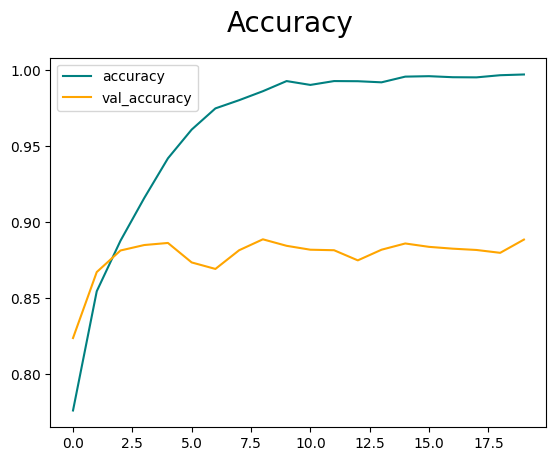

```python
fig = plt.figure()
plt.plot(hist.history['accuracy'], color='teal', label='accuracy')
plt.plot(hist.history['val_accuracy'], color='orange', label='val_accuracy')
fig.suptitle('Accuracy', fontsize=20)
plt.legend(loc="upper left")
plt.show()
```

# 9. Evaluate

```python
from tensorflow.keras.metrics import Precision, Recall, BinaryAccuracy
```

```python
pre = Precision()
re = Recall()
acc = BinaryAccuracy()
```

```python
for batch in test.as_numpy_iterator():
    X, y = batch
    yhat = model.predict(X)
    pre.update_state(y, yhat)
    re.update_state(y, yhat)
    acc.update_state(y, yhat)
```

```python
print("Precision:",pre.result(),"\n Recall:", re.result(), "\n Accuracy:",acc.result())
```

```
Precision: tf.Tensor(0.90414876, shape=(), dtype=float32)
 Recall: tf.Tensor(0.9230769, shape=(), dtype=float32)
 Accuracy: tf.Tensor(0.87671703, shape=(), dtype=float32)
```

# 10. Test

```python
import cv2
```

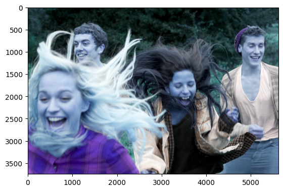

```python
img = cv2.imread('154006829.jpg')
plt.imshow(img)
plt.show()
```

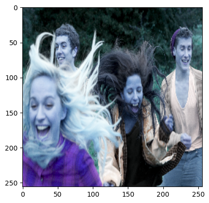

```python
resize = tf.image.resize(img, (256,256))
plt.imshow(resize.numpy().astype(int))
plt.show()
```

```python
yhat = model.predict(np.expand_dims(resize/255, 0))
```

```python
yhat
```

```
array([[0.99949515]], dtype=float32)
```

```python
if yhat > 0.5:
    print(f'Predicted class is Not Cat')
else:
    print(f'Predicted class is Cat')
```

```
Predicted class is Not Cat
```

# 11. Save the Model

```python
from tensorflow.keras.models import load_model
```

```python
model.save(os.path.join('models','imageclassifier.h5'))
```

```python
new_model = load_model('imageclassifier.h5')
```

[output not shown]

```python
new_model.predict(np.expand_dims(resize/255, 0))
```